# Patient Data Report for Vancouver Coastal Health

**Prepared By: Gurpal Bisra and Leon Zhu**

**Date: September 25, 2016**

## Executive Summary

As per the request of the Vancouver Coastal Health, we have generated this report by using the recieved confidental patient data. We identified the mean features of the data and their combinations such that one can deduce information to make decisions, to meet the healthcare needs of the population, within Vancouver Coastal Health.

We received two data files, named “admissions.csv” and “ptdata.csv.” For each file, we read in the files into R, cleaned and formatted the data. We then merged the two data frames into a new one. Next, we performed exploratory data analysis.

## Tidying Data

We received two data files, named “admissions.csv” and “ptdata.csv.” For each file, we read in the files into R, cleaned and formatted the data. For “admissions.csv,” we added the column weekdayname and a column weekdayname with factor levels of days of the week, and changed the “emerg” column’s data type from int to factor and “amdate” column’s data type from factor to POSITlt type. For “ptdata.csv,” we created a new column named “age” with numeric data types, removed “hr” from the data values, changed the “age” column’s data type from char to numeric, removed values containing -1 and created a new column named “agegroup.” This columnn contains counts of anyone who falls into sets of 5 years ranging from *0* up to *90+*. Finally, we changed the “agegroup” data type from numeric to factor.

After the two data frames were edited, we merge the two data frames into a new one. The final data frame contained the fields we deemed most important to include in this report. **The columns are denoted with their data-types as follows:**

1. id as integer
2. sex as factor
3. age as numeric with range 1 to 99
4. agegroup as factor (5 year age bins, from 0 to 90)
5. emerg as factor
6. admdate as date
7. weekdayname as factor
8. los as numeric

Detailed data dictionaries of the original data are found at the end of this report.

Table 1 below details the data dictionary of the tidy merged data frame, denoted as “admp,” which was used for exploratory data analysis.

### TABLE 1: DATA DICTIONARY FOR MERGED DATA (admp) DATA FRAME

| Column Name | Format | Length | Data Elements [Range] | Description |
| --- | --- | --- | --- | --- |
| id | int | 40,000 | [3, 30,000], missing values | Patient identification number |
| sex | Factor | 40,000 | M is male, F is female, NA is “unknown” | Chromosomal male or female |
| age | num | 40,000 | [1, 99] | Age in years |
| agegroup | Factor | 40,000 | [0, 90] by 5-year intervals | Age group of 5-year intervals |
| emerg | Factor | 40,000 | 0 for “no”, or 1 for “yes” | Emergency room patient or not |
| admdate3 | Date | 40,000 | [2014-01-01, 2014-12-30] | Patient admission date |
| weekdayname | Factor | 40,000 | M, T, W, Th, F, Sa, Su | Days of the week |
| los | num | 40,000 | [0.1828703, 267.37636] | Length of hospital stay in days |

# Exploratory Data Analysis

After tidying the data we recieved, we performed exploratory data analysis and determined interesting trends.

First, we plotted the frequency of admissions by the days of the week. We observed a higher number of reported admissions during the weekdays when compared to the weekends.

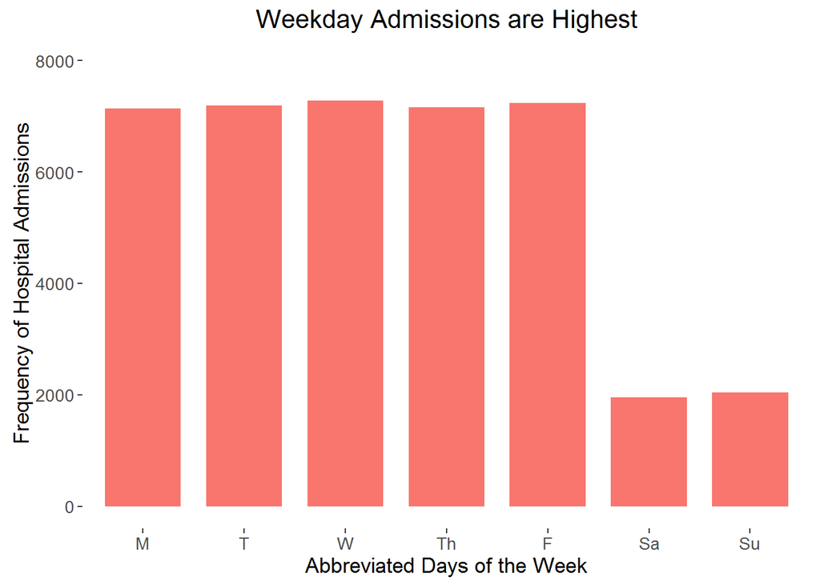

Next, we plotted the frequency of emergency and non-emergency visits as a function of the days of the week. Interestingly, we observed little variation in the number of emergency visits across every day of the week.

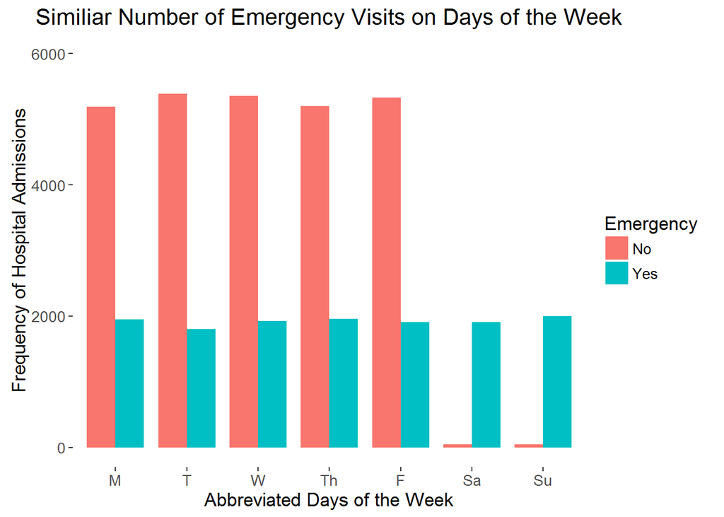

Afterwards, we plotted the density of genders, both male and female, as a function of their length of hospital stay. We visually observed both distributions to be right-skewed and similiar.

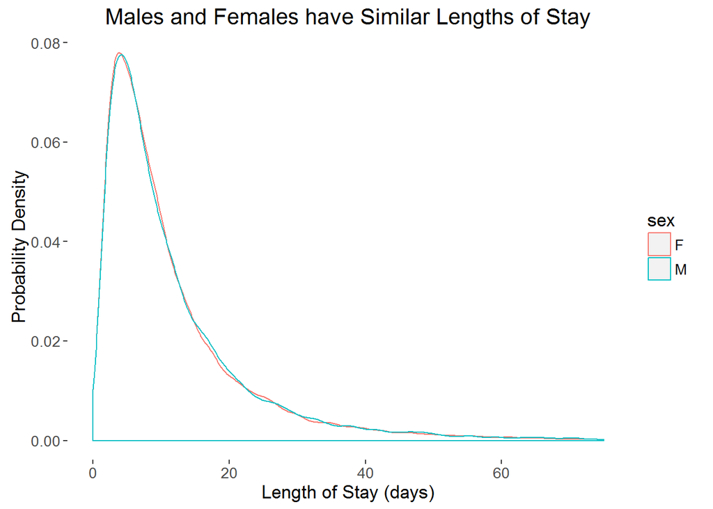

In addition, we plotted the frequency of hospital admissions for each month. We noted that, on average, there are more female than male admissions each month. The exceptions occured in February and June.

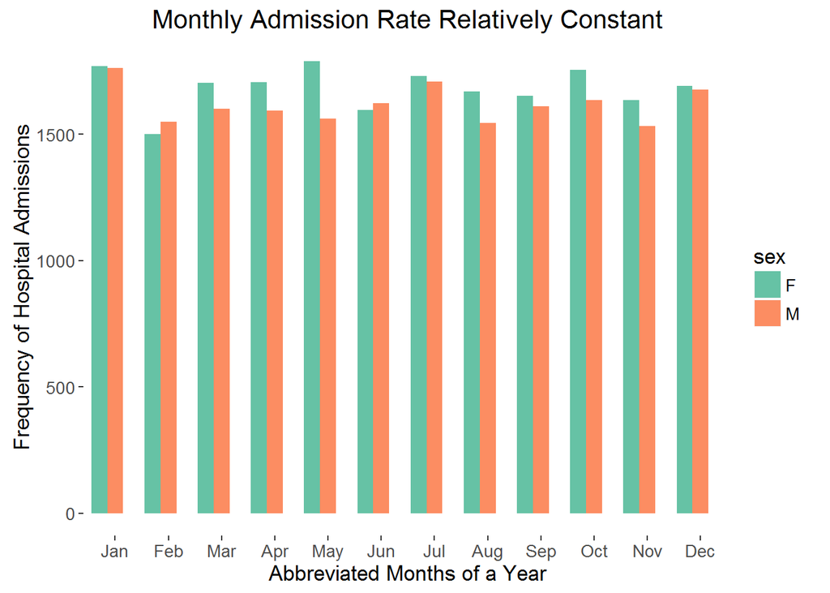

Furthermore, we plotted the average length of hospital stay in days against each month in 2014. We observed similar average lengths of stay across all months.

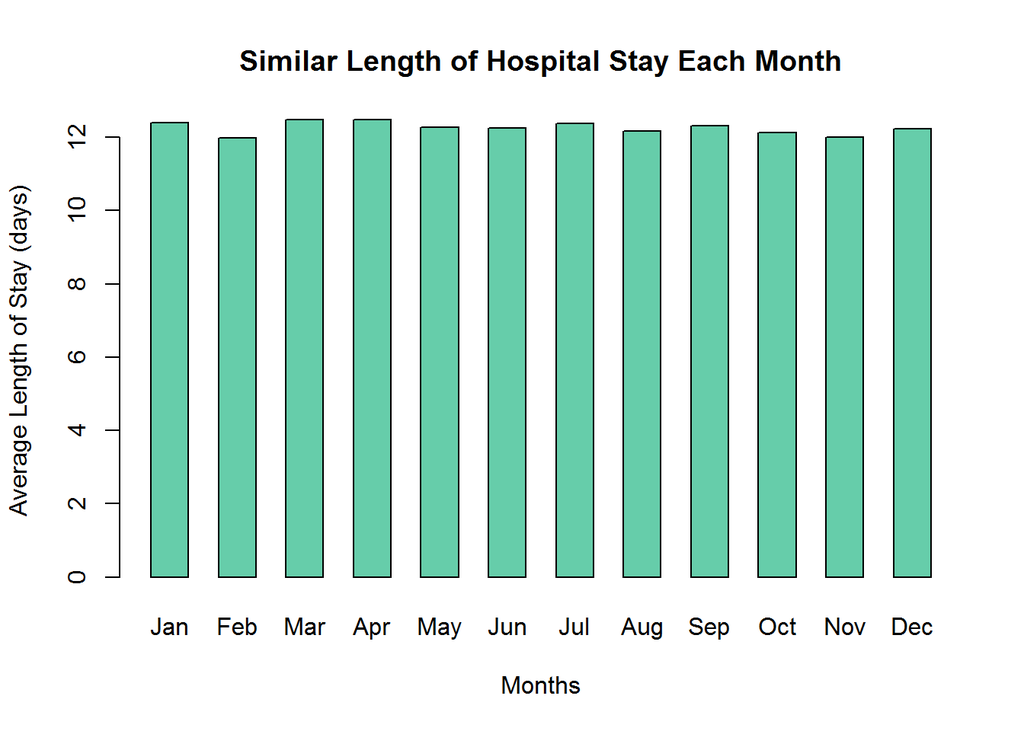

Next, we explored combinations which included various age groups. First, we plotted a histogram of the admission rates against their respective age groups. Interestingly, we observed a normal distribution.

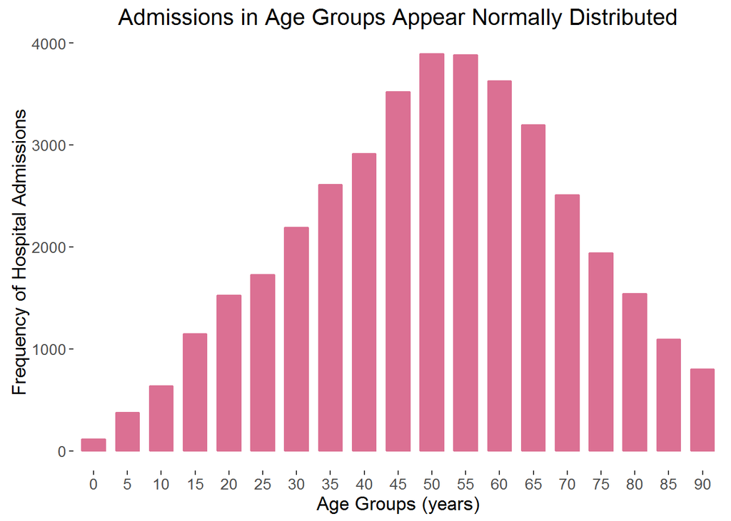

Similarily, we then plotted a histogram of the average length of stay for all age groups. We observed a similar average length of stay, in days, for all age groups.

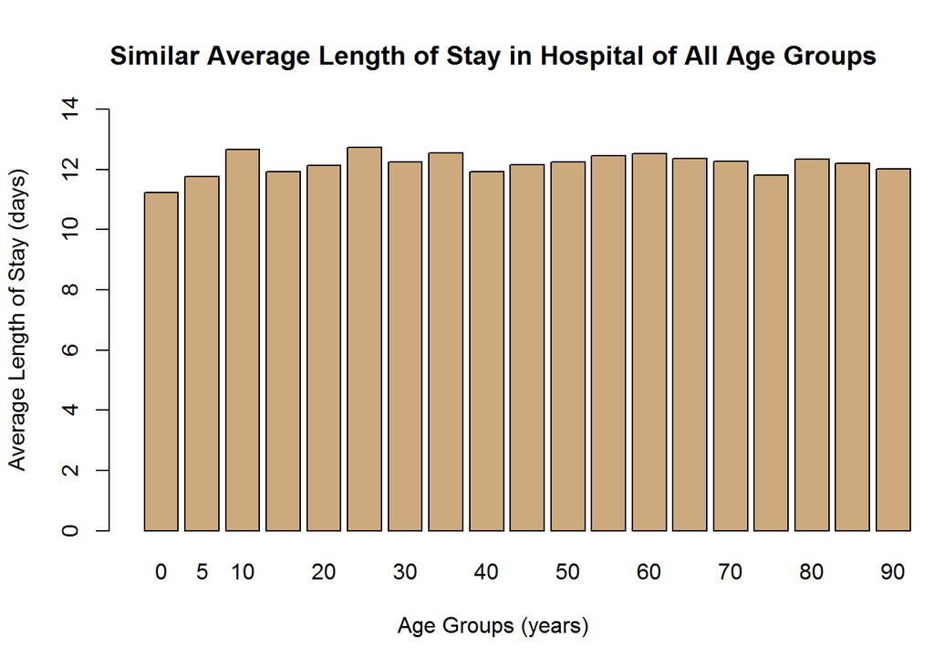

[figure not shown]

Finally, we tabulated a table of the frequency of male and female patients corresponding to each age group. For instance, each age group is different by 5-years and the last group accounts for those who are over 90-years-old.

| agegroup | Female | Male |
| --- | --- | --- |
| 0 | 54 | 60 |
| 5 | 199 | 174 |
| 10 | 265 | 369 |
| 15 | 592 | 539 |
| 20 | 700 | 808 |
| 25 | 798 | 896 |
| 30 | 1092 | 1072 |
| 35 | 1298 | 1282 |
| 40 | 1480 | 1417 |
| 45 | 1762 | 1724 |
| 50 | 1946 | 1910 |
| 55 | 1900 | 1938 |
| 60 | 1794 | 1806 |
| 65 | 1589 | 1570 |
| 70 | 1300 | 1191 |
| 75 | 1020 | 889 |
| 80 | 802 | 731 |
| 85 | 663 | 429 |
| 90 | 556 | 240 |

# Conclusions

# Data Dictionary

### TABLE 2: DATA DICTIONARY FOR ADMISSIONS (adm) DATA FRAME

| Column Name | Format | Length | Data Elements [Range] | Description |
| --- | --- | --- | --- | --- |
| id | int | 40,000 | [3, 30,000], missing values | Patient identification number |
| emerg | Factor | 40,000 | 0 for “no”, or 1 for “yes” | Emergency room patient |
| sched | Factor | 40,000 | Scheduled, Unscheduled, NA | Scheduled patient or not |
| admdate | Factor | 40,000 | [2014-01-01, 2014-12-30] | Patient admission date |
| los | num | 40,000 | [0.1828703, 267.37636] | Length of hospital stay in days |

### TABLE 3: DATA DICTIONARY FOR PATIENT DATA (ptdata) DATA FRAME

| Column Name | Format | Length | Data Elements [Range] | Description |
| --- | --- | --- | --- | --- |
| id | int | 30,000 | [1, 30,000] | Patient identification number |
| sex | Factor | 30,000 | M is male, F is female, NA is “unknown” | Chromosomal male or female |
| age2 | Factor | 30,000 | [-1yr, 99yr] | Age in years |